# Práctica 1 - Módulo 3

Introducción al modelado de datos

Diplomatura en Ciencias Sociales Computacionales y Humanidades Digitales (IDAES-UNSAM)

> Material elaborado originalmente por Carolina Pradier y Guido Weksler

```r
library(tidyverse)
library(viridis)
library(ggridges)
options(dplyr.summarise.inform = FALSE)
```

# 1 Análisis exploratorio de una base de datos

En esta clase vamos a explorar una versión reducida de los resultados del Módulo de Trabajo no Remunerado (MTNR) de la Encuesta Anual de Hogares Urbanos (EAHU) del INDEC para 2013. En esta base de datos encontramos información respecto al uso del tiempo de la población (en particular, las horas dedicadas al trabajo no remunerado).

```r
base_EAUH_TNR <- readRDS("./fuentes/base_EAUH_TNR.RDS") %>%
  rename("Sexo" = "CH04")
```

*Nota:* al tratarse de una encuesta, deberíamos recurrir al **ponderador** de cada observación para calcular medidas de resumen adecuadamente. Por tratarse de un curso introductorio de programación donde el objetivo principal es ilustrar el uso de las herramientas de R, se simplifica el ejercicio tomando cada fila como una observación.

Veamos qué hay en la base:

```r
names(base_EAUH_TNR)
```

```
##  [1] "TIEMPO_TDNR"               "JURISDICCION"
##  [3] "Sexo"                      "CH06"
##  [5] "NIVEL_ED"                  "posicion_hogar"
##  [7] "ama_de_casa"               "categoria"
##  [9] "horas_mercado"             "ingreso_indiv"
## [11] "JERARQUIA"                 "CALIFICACION"
## [13] "IPCF"                      "SERVICIO_DOMESTICO_U_OTRA"
## [15] "menores_hogar"             "mayores_hogar"
## [17] "discapac_en_hogar"         "adultos_hogar"
```

```r
head(base_EAUH_TNR,10)
```

```
##    TIEMPO_TDNR     JURISDICCION  Sexo CH06                          NIVEL_ED
## 1          2.5     Buenos Aires Varón   27 Superior Universitaria Incompleta
## 2          3.0     Buenos Aires Mujer   38 Superior Universitaria Incompleta
## 3          4.0          Mendoza Varón   38               Secundaria Completa
## 4         12.0          Mendoza Mujer   43               Secundaria Completa
## 5          0.0         Santa Fe Mujer   53                 Primaria Completa
## 6          0.0         Santa Fe Mujer   29             Secundaria Incompleta
## 7          0.0         Santa Fe Varón   27             Secundaria Incompleta
## 8          1.5         Santa Fe Varón   26             Secundaria Incompleta
## 9          3.0            Salta Varón   23 Superior Universitaria Incompleta
## 10         4.0 Tierra del Fuego Varón   29 Superior Universitaria Incompleta
##        posicion_hogar ama_de_casa                categoria horas_mercado
## 1              Jefe/a          No Asalariadx No Registradx            57
## 2              Pareja          Si      Desocupado/Inactivo             0
## 3              Jefe/a          No    Asalariadx Registradx            72
```

[output cut: 40 more lines]

# 2 Repaso de estadística

Antes de empezar, repasemos algunos conceptos.

## 2.1 Media

La **media** es un promedio no ponderado: sumamos todos los valores de la muestra y luego dividimos por la cantidad de elementos.

$$\overline{x} = \frac{1}{n}
\sum_{i=1}^{n} x_{i}$$

¿Cómo lo calculamos en R?

```r
mean(c(1,2,3,4))
```

```
## [1] 2.5
```

## 2.2 Varianza y desvío estándar

*Nota:* ¿por qué está elevada al cuadrado?

¿Cómo la calculamos en R?

```r
var(c(1,2,3,4))
```

```
## [1] 1.666667
```

El **desvío estándar** nos brinda una información similar a la varianza, pero al calcular su raíz cuadrada, la llevamos a la misma unidad que la variable original, haciéndola más comparable.

¿Cómo lo calculamos en R?

```r
sd(c(1,2,3,4))
```

```
## [1] 1.290994
```

```r
sd(c(1,2,3,4))**2
```

```
## [1] 1.666667
```

# 3 Graficando una distribución

Para comenzar a familiarizarnos con una base de datos y luego construir un modelo, es útil visualizar la distribución de sus variables y las relaciones entre ellas.

¿Cómo se distribuye la variable con información sobre las horas dedicadas al trabajo doméstico no remunerado?

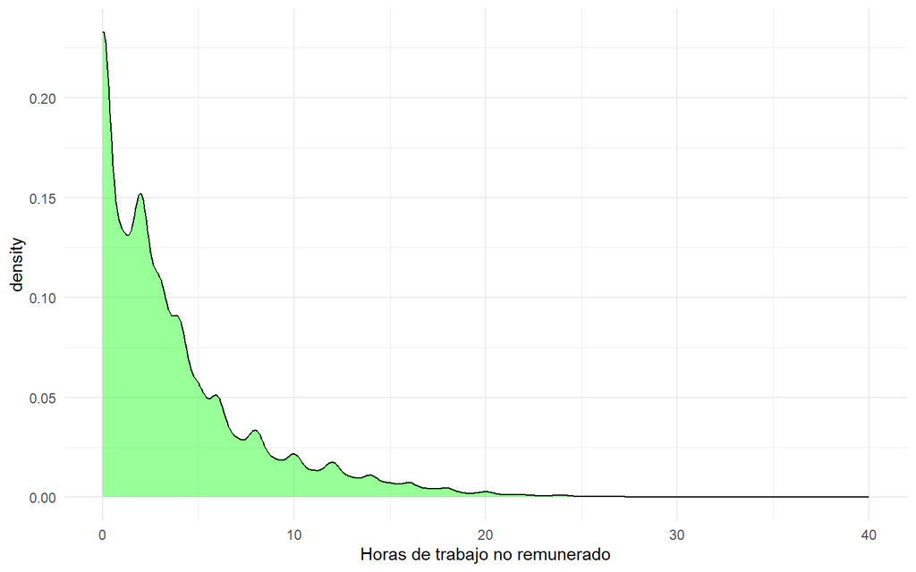

```r
base_EAUH_TNR %>%
  filter(CH06 > 17) %>% #Mayores de 18
ggplot(aes(x=TIEMPO_TDNR)) +
    geom_density(adjust=1.5, alpha=.4, fill = "green") +
    theme_minimal()+
  xlab("Horas de trabajo no remunerado") +
  xlim(0,40)
```

¿Es igual para las personas de ambos sexos?

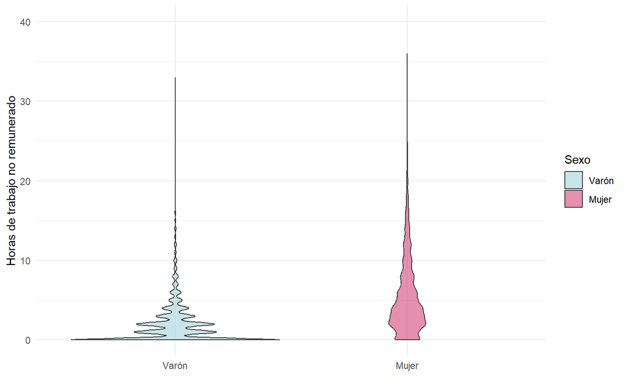

```r
base_EAUH_TNR %>%
  filter(CH06 > 17) %>%
ggplot(aes(fill=Sexo, y=TIEMPO_TDNR, x=Sexo)) +
    geom_violin(position="dodge", alpha=0.5, outlier.colour="transparent") +
    scale_fill_manual(values = c("#91CBD765","#CA225E"))+
    theme_minimal()  +
    xlab("") +
    ylab("Horas de trabajo no remunerado") +
    ylim(0,40)
```

¿Cómo se relaciona con las horas de trabajo remunerado?

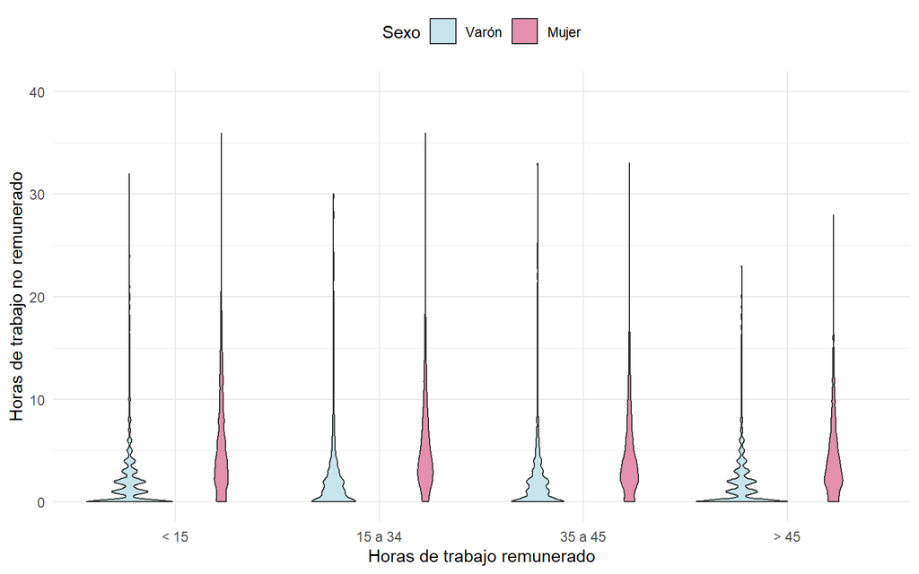

```r
base_EAUH_TNR %>%
  filter(CH06 > 17) %>%
  filter(!is.na(horas_mercado)) %>%
mutate(horas_mercado_agrup = factor(case_when(horas_mercado < 15~ "< 15",
                                              horas_mercado %in% 15:34~ "15 a 34",
                                              horas_mercado %in% 35:45~ "35 a 45",
                                              horas_mercado > 45~ "> 45"),
                                    levels = c( "< 15","15 a 34","35 a 45","> 45"))) %>%
ggplot(aes(y=TIEMPO_TDNR, x =horas_mercado_agrup , fill=Sexo)) +
    geom_violin(position="dodge", alpha=0.5, outlier.colour="transparent") +
    theme_minimal()  +
    ylim(0,40)+
  ylab("Horas de trabajo no remunerado") +
  xlab("Horas de trabajo remunerado") +
  theme(legend.position = "top")+
  scale_fill_manual(values = c("#91CBD765","#CA225E"))
```

¿Cómo se relaciona con los ingresos individuales?

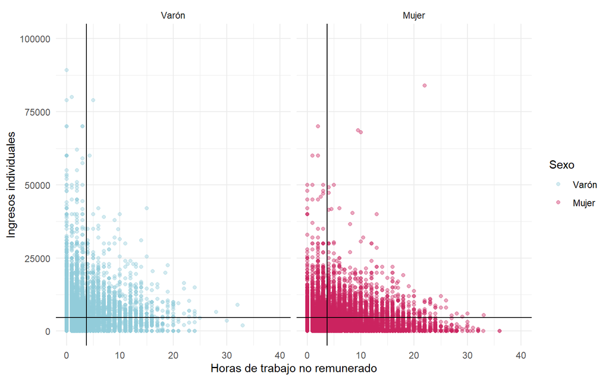

```r
base_EAUH_TNR%>%
  filter(CH06 > 17) %>%
ggplot(aes(x=TIEMPO_TDNR, y=ingreso_indiv, color = Sexo)) +
  geom_point(alpha = 0.4) +
  ylim(0,100000)+
  xlim(0,40)+
  ylab("Ingresos individuales") +
  xlab("Horas de trabajo no remunerado") +
  geom_hline(yintercept = mean(base_EAUH_TNR$ingreso_indiv[base_EAUH_TNR$ingreso_indiv >0]),
             linewidth = 0.5)+
  geom_vline(xintercept = mean(base_EAUH_TNR$TIEMPO_TDNR), linewidth = 0.5)+
  theme_minimal()+
  scale_color_manual(values = c("#91CBD968","#CA225E"))+
  facet_wrap(~Sexo)
```

¿Y si hay menores en el hogar?

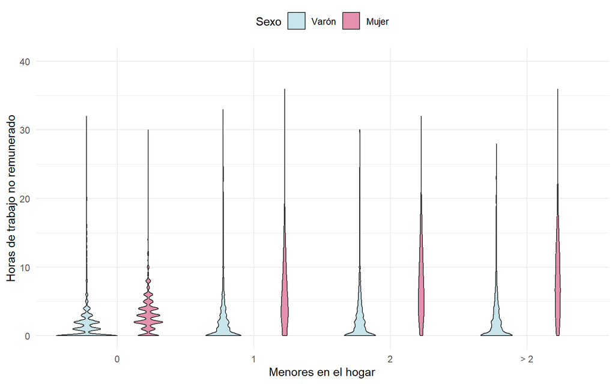

```r
base_EAUH_TNR %>%
  mutate(menores_hogar_agrup = factor(case_when(menores_hogar == 0~ "0",
                                              menores_hogar  == 1~ "1",
                                              menores_hogar  == 2~ "2",
                                              menores_hogar > 2~ "> 2"),
                                    levels = c( "0","1","2","> 2"))) %>%
  filter(CH06 > 17) %>%
ggplot(aes(fill=Sexo, y=TIEMPO_TDNR, x=menores_hogar_agrup)) +
    geom_violin(position="dodge", alpha=0.5, outlier.colour="transparent") +
    scale_fill_manual(values = c("#91CBD765","#CA225E"))+
    theme_minimal()  +
    xlab("Menores en el hogar") +
    ylab("Horas de trabajo no remunerado") +
    ylim(0,40)+
  theme(legend.position = "top")
```

# 4 Correlación. Definición y técnicas para su visualización

La correlación describe la **fuerza** y la **dirección** de la relación lineal entre dos variables. Puede tomar valores entre -1 (relación negativa perfecta) y 1 (relación positiva perfecta), pasando por 0 (si no existe una relación lineal). Su valor no tiene unidades y no es sensible a transformaciones lineales en las variables.

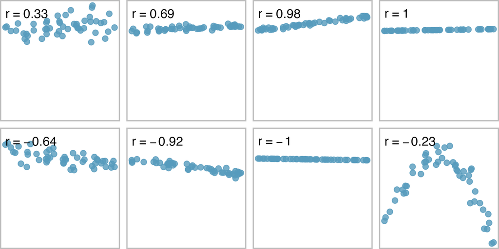

Esta figura muestra ocho parcelas y sus correlaciones correspondientes. Solo cuando la relación es perfectamente lineal, la correlación es -1 o 1. Si la relación es fuerte y positiva, la correlación será cercana a +1. Si es fuerte y negativa, estará cerca de -1. Si no existe una relación lineal aparente entre las variables, entonces la correlación será cercana a cero.

Podemos calcular la correlación usando la siguiente fórmula:

$$\rho_{xy} \equiv r_{xy} =
\frac{\sum_{i=1}^n (x_{i} - \overline{x}_{i})(y_{i} -
\overline{y}_{i})}{\sqrt{\sum_{i=1}^n (x_{i} - \overline{x}_{i})^2}
\sqrt{\sum_{i=1}^n (y_{i} - \overline{y}_{i})^2}}=\frac{\sum_{i=1}^n
(x_{i} - \overline{x}_{i})(y_{i} - \overline{y}_{i})}{(n - 1)s_x s_y}
=\frac{cov(x,y)}{s_x s_y}$$

La correlación es una forma “normalizada” de la *covarianza*, para que esté entre -1 y 1. Es decir que si dos variables tienen una relación lineal fuerte y positiva, podemos decir que tienen elevada correlación o elevada covarianza. Noten que el nombre “covarianza” viene de que se calcula muy parecido a la varianza (la varianza es, de hecho, la covarianza de una variable consigo misma).

## 4.1 Matriz de correlación

La **matriz de correlación** nos permite visualizar rápidamente las principales relaciones entre las variables. Es una herramienta que puede resultar útil para seleccionar las variables explicativas en un modelo.

Calculemos la matriz de correlaciones para nuestra base (sólo se calculan entre variables numéricas!):

```r
corr <- base_EAUH_TNR %>%
  # Seleccionamos las columnas numéricas
  select_if(is.numeric) %>%
  # Calculamos la matriz de correlaciones
  cor()

corr
```

```
##               TIEMPO_TDNR        CH06 horas_mercado ingreso_indiv        IPCF
## TIEMPO_TDNR    1.00000000 -0.08096715   -0.19412348   -0.11434125 -0.10222491
## CH06          -0.08096715  1.00000000   -0.17214919    0.13695999  0.14359945
## horas_mercado -0.19412348 -0.17214919    1.00000000    0.39452219  0.13851175
## ingreso_indiv -0.11434125  0.13695999    0.39452219    1.00000000  0.66563705
## IPCF          -0.10222491  0.14359945    0.13851175    0.66563705  1.00000000
## menores_hogar  0.27047826 -0.28677450    0.07400951   -0.06466864 -0.30653289
## mayores_hogar -0.08147502  0.49817415   -0.22909809   -0.02842518  0.03874651
## adultos_hogar -0.05793129 -0.36805080    0.05613035   -0.13965182 -0.21118457
##               menores_hogar mayores_hogar adultos_hogar
## TIEMPO_TDNR      0.27047826   -0.08147502   -0.05793129
## CH06            -0.28677450    0.49817415   -0.36805080
## horas_mercado    0.07400951   -0.22909809    0.05613035
## ingreso_indiv   -0.06466864   -0.02842518   -0.13965182
## IPCF            -0.30653289    0.03874651   -0.21118457
## menores_hogar    1.00000000   -0.20437406    0.28168350
## mayores_hogar   -0.20437406    1.00000000   -0.35014608
## adultos_hogar    0.28168350   -0.35014608    1.00000000
```

Para ver mejor las relaciones entre las variables, podemos recurrir a la librería *corrplot*.

```r
library(corrplot)
```

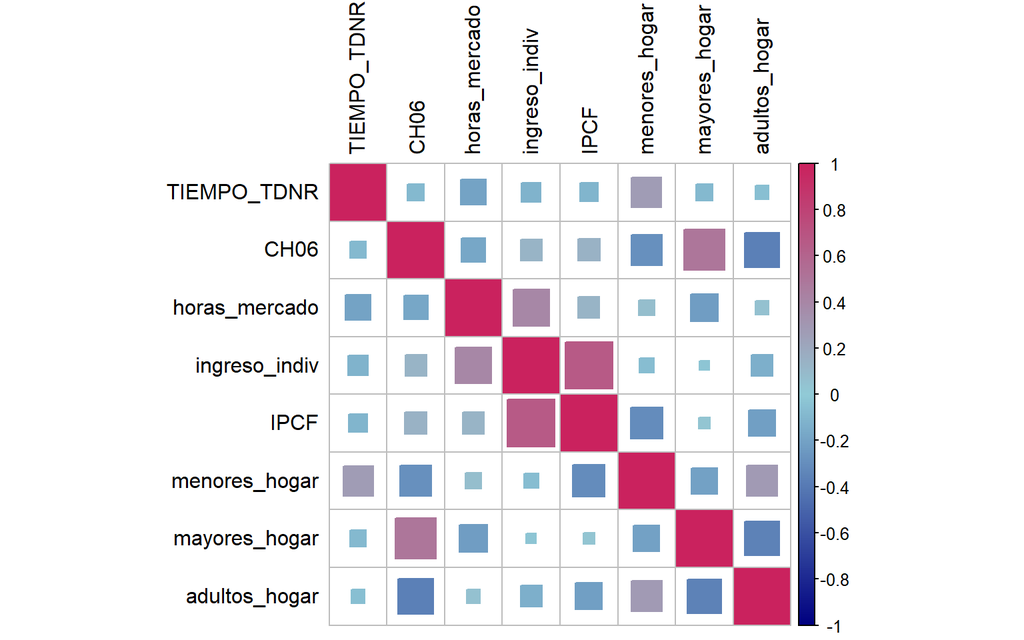

```r
#Graficamos con nuestro propio espectro de colores
mi_paleta <- colorRampPalette(c("navy","#91CBD765", "#CA225E"))

corr %>%
  corrplot(col = mi_paleta(200), tl.col = "black", method = "square")
```

¿Alguna relación entre variables les llama la atención?

# 5 Resumen

- Antes de modelar, siempre es útil llevar a cabo un análisis exploratorio de la base de datos para luego elegir las variables relevantes para la construcción del modelo.
- Principales medidas de resumen: media, varianza y desvío estándar.
- Correlación, ¿qué significa? ¿Cómo se calcula?

# 6 Referencias bibliográficas

An Introduction to Statistical Learning with applications in R (James, Witten, Hastie y Tibshirani) – 1st and 2nd version

Tidy Modeling with R (Kuhn y Silge)

Introduction to Modern Statistics (Çetinkaya-Rundel y Hardin)